# Bool Net tutorial

Roberto Álvarez

13 marzo, 2023

# 1 BoolNet

```r
library(BoolNet)
```

## 1.1 Cómo generar una red booleana

Para generar una red booleana debemos identificar los elementos participantes en ella y sus relaciones de regulación. Analizaremos el siguiente ejemplo:

[figure not shown]

Red Booleana tomada de **Boolean modeling in systems biology: an overview of methodology and applications** Rui-Sheng Wang, Assieh Saadatpour Réka Albert

1. Traducir las reglas en formato de texto (recuerda que los operadores bboleanos en R se escriben de la siguiente manera: `AND` es **&**, `OR` es **|**, `NOT` es **!**)
2. Usar un archivo de texto plano. Repito plano. Plano significa no Word, no Doogle Docs, no Pages, etc. Qué sí es un texto plano: el bloc de notas, texedit nano, gedit, etc. Con ello generamos un archivo de texto con la siguiente estructura:

```
targets , factors
```

Es decir un archivo de texto con dos columnas separadas por una coma. En la primera columna ponemos el nombre del elemento en este caso: **V1**, **V2** y **V3**. En la segunda, ponemos las reglas. Guaradmos el archivo por ejemplo podemos ponerle `MyNet.txt`

```
targets , factors
V1 , V1 | ! V3
V2 , V1 & V3
V3, V2
```

A veces se tiene problemas con este tipo de archivos. Pero se puede hacer desde R con la siguiente instrucción :

```r
# write example network to file
fil <- tempfile(pattern = "testNet")
sink(fil)
cat("targets, factors\n")
cat("V1, V1 | !V3\n")
cat("V2, V1 & V3\n")
cat("V3, V2\n")
sink()

### Cargar la red
mi_red<-loadNetwork(fil)
```

3. Cargar la red, es decir el archivo de texto generado si lo hiciste con un archivo de texto llamado `"MyNet.txt"`con un editor externo

```r
mi_red<-loadNetwork("C:/Users/rober/OneDrive - UAQ/MyNet.txt")
mi_red
```

```
## Boolean network with 3 genes
##
## Involved genes:
## V1 V2 V3
##
## Transition functions:
## V1 = V1 | !V3
## V2 = V1 & V3
## V3 = V2
```

## 1.2 Atractores

```r
mis_atractores <- getAttractors(mi_red)
mis_atractores
```

```
## Attractor 1 is a simple attractor consisting of 1 state(s) and has a basin of 4 state(s):
##
##  |--<--|
##  V     |
##  100   |
##  V     |
##  |-->--|
##
##
## Genes are encoded in the following order: V1 V2 V3
##
## Attractor 2 is a simple attractor consisting of 1 state(s) and has a basin of 1 state(s):
##
##  |--<--|
##  V     |
##  111   |
##  V     |
##  |-->--|
##
##
## Genes are encoded in the following order: V1 V2 V3
##
## Attractor 3 is a simple attractor consisting of 2 state(s) and has a basin of 3 state(s):
##
##  |--<--|
##  V     |
##  110   |
##  101   |
##  V     |
##  |-->--|
##
##
## Genes are encoded in the following order: V1 V2 V3
```

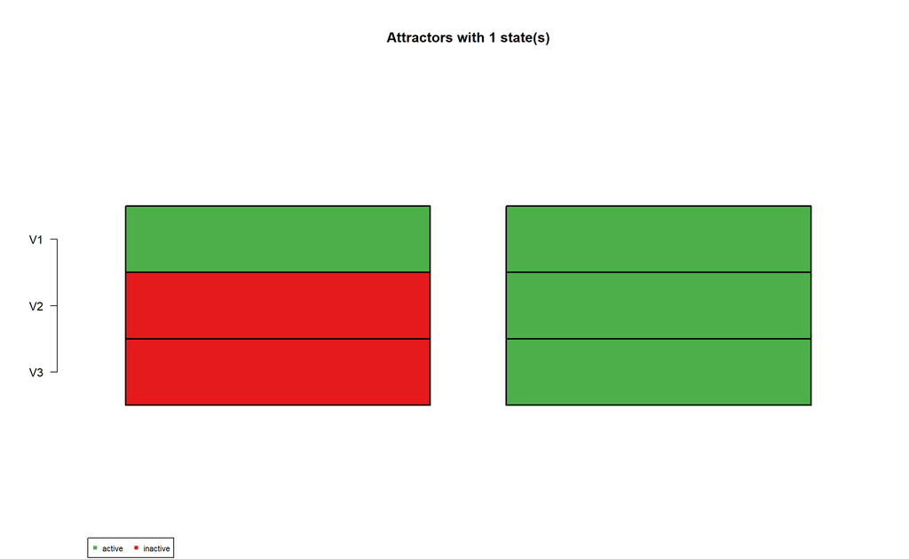

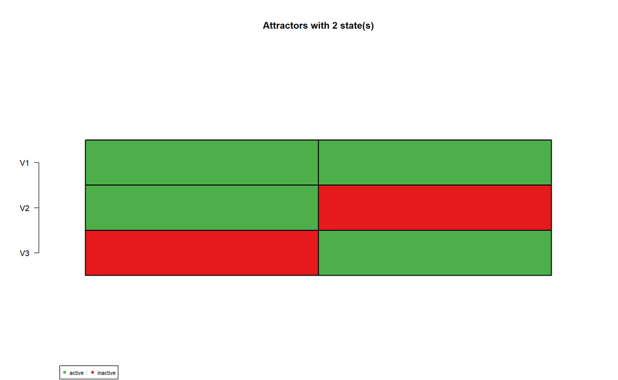

```
## $`1`
##    Attr1.1 Attr2.1
## V1       1       1
## V2       0       1
## V3       0       1
##
## $`2`
##    Attr3.1 Attr3.2
## V1       1       1
## V2       1       0
## V3       0       1
```

```r
plotAttractors(mis_atractores)
```

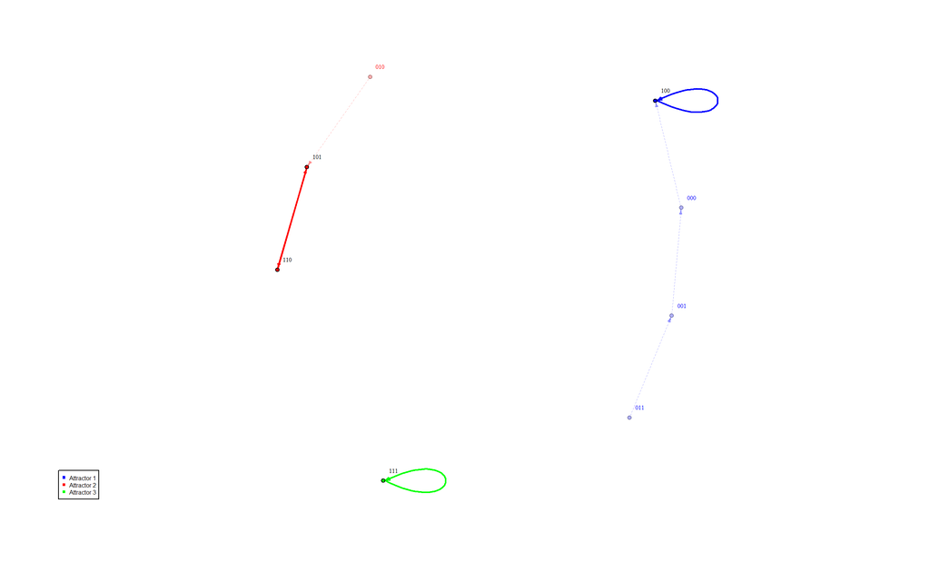

```r
plotStateGraph(mis_atractores,drawLabels = TRUE)
```

**Ejercicio**

1. Carga una red que hayas generado a mano
2. Interpreta tus resultados y corrobora que lo que encontraste corresponde lo que calculaste manualmente.

## 1.3 Descargar modelos ya publicados en SBML

```r
otra<-loadSBML("BIOMD0000000592_url.xml")
```

```r
otra
```

```
## Boolean network with 10 genes
##
## Involved genes:
## TBET GATA3 FOXP3 RORGT BCL6 TH1e TH2e TREGe TH17e TFHe
##
## Transition functions:
## TBET = ((TH1e | TBET) & !(GATA3 | BCL6))
## GATA3 = ((TH2e | GATA3) & !(TBET | BCL6))
## FOXP3 = ((TREGe | FOXP3) & !RORGT)
## RORGT = (TH17e & !(TBET | GATA3 | FOXP3 | BCL6))
## BCL6 = (TFHe & !TBET)
## TH1e = TH1e
## TH2e = TH2e
## TREGe = TREGe
## TH17e = TH17e
## TFHe = TFHe
```

**Ejercicios**